# Sentiment Analysis and Emotion Analysis In Python - April 2024

```python
import pandas as pd
import sys
import re
import nltk
nltk.download('wordnet')
nltk.download('omw-1.4')
from nltk.stem import WordNetLemmatizer
pd.set_option('mode.chained_assignment', None)
```

Original dataset can be found here: https://www.kaggle.com/datasets/manishkumar7432698/airline-passangers-booking-data

```python
data=pd.read_csv('AirlineScrappedReview.csv')
data.head()
```

|  | Passanger_Name | Flying_month | Route | Rating | Verified | Review_title | Review_content | Traveller_type | Class |
| --- | --- | --- | --- | --- | --- | --- | --- | --- | --- |
| 0 | Paige Boet | June 2023 | New Orleans to London | 1.0 | Trip Verified | The airline lost my luggage | The airline lost my luggage and was absolutely... | Solo Leisure | Economy Class |
| 1 | S Layne | March 2023 | London to Amman | 1.0 | Trip Verified | fully refunded by our travel insurance | We booked on the BA website, round trip flight... | Couple Leisure | Business Class |
| 2 | E Lanewoski | Heathrow to Bodrum | Business Class | 2.0 | Trip Verified | no boarding drinks provided | First time flying with BA business class, neve... | A321 neo | Solo Leisure |
| 3 | Joel Burman | June 2023 | Amman to London | 4.0 | Not Verified | WiFi didn't work | You can buy sandwiches and crisps but don't ex... | Solo Leisure | Economy Class |
| 4 | R Vines | London City to Ibiza | Business Class | 7.0 | Trip Verified | stick with economy | This is a two-for-one review covering economy ... | Embraer 190 | Family Leisure |

```python
data.describe()
```

|  | Rating |
| --- | --- |
| count | 3575.000000 |
| mean | 4.790490 |
| std | 3.170323 |
| min | 1.000000 |
| 25% | 2.000000 |
| 50% | 4.000000 |
| 75% | 8.000000 |
| max | 10.000000 |

```python
data.info()
```

```
<class 'pandas.core.frame.DataFrame'>
RangeIndex: 3580 entries, 0 to 3579
Data columns (total 9 columns):
 #   Column          Non-Null Count  Dtype
---  ------          --------------  -----
 0   Passanger_Name  3580 non-null   object
 1   Flying_month    2815 non-null   object
 2   Route           2816 non-null   object
 3   Rating          3575 non-null   float64
 4   Verified        1270 non-null   object
 5   Review_title    3580 non-null   object
 6   Review_content  3580 non-null   object
 7   Traveller_type  3580 non-null   object
 8   Class           3579 non-null   object
dtypes: float64(1), object(8)
memory usage: 251.8+ KB
```

# Sentiment Analysis

```python
pip install vaderSentiment
```

The output of Vader is a composite score that ranges from -1 to 1. Therefore, we define the polarity of the comment to be judged based on the score computed by the review at different value intervals. Specifically, when the score < -0.05, the polarity of the review is judged to be negative, when the score > 0.05, the polarity of the review is judged to be positive, and when -0.05<score<0.05, the polarity of the review is judged to be neural. We newly defined two features, sentiment_title and sentiment_content, as the storage variables for the results of vader lexicon runs. (As later I will compare the Rating variable with sentiment_title and sentiment_content to see which new feature is more matching and have a further analysis.

```python
from vaderSentiment.vaderSentiment import SentimentIntensityAnalyzer
df=data[['Review_title','Review_content']]
analyzer = SentimentIntensityAnalyzer()
compound_title=[]
sentiment_title=[]
compound_content=[]
sentiment_content=[]
for index,row in df.iterrows():
    vs1=analyzer.polarity_scores(row['Review_title'])
    vs2=analyzer.polarity_scores(row['Review_content'])
    if vs1['compound']<=-0.05:
        sentiment_title.append('neg')
    elif vs1['compound']>=0.05:
        sentiment_title.append('pos')
    else:
        sentiment_title.append('neu')
    compound_title.append(vs1['compound'])
    if vs2['compound']<=-0.05:
        sentiment_content.append('neg')
    elif vs2['compound']>=0.05:
        sentiment_content.append('pos')
    else:
        sentiment_content.append('neu')
    compound_content.append(vs2['compound'])

data['compound_title']=compound_title
data['sentiment_title']=sentiment_title
data['compound_content']=compound_content
data['sentiment_content']=sentiment_content
```

```python
data
```

|  | Passanger_Name | Flying_month | Route | Rating | Verified | Review_title | Review_content | Traveller_type | Class | compound_title | sentiment_title | compound_content | sentiment_content |
| --- | --- | --- | --- | --- | --- | --- | --- | --- | --- | --- | --- | --- | --- |
| 0 | Paige Boet | June 2023 | New Orleans to London | 1.0 | Trip Verified | The airline lost my luggage | The airline lost my luggage and was absolutely... | Solo Leisure | Economy Class | -0.3182 | neg | -0.7990 | neg |
| 1 | S Layne | March 2023 | London to Amman | 1.0 | Trip Verified | fully refunded by our travel insurance | We booked on the BA website, round trip flight... | Couple Leisure | Business Class | 0.0000 | neu | 0.0219 | neu |
| 2 | E Lanewoski | Heathrow to Bodrum | Business Class | 2.0 | Trip Verified | no boarding drinks provided | First time flying with BA business class, neve... | A321 neo | Solo Leisure | -0.2960 | neg | -0.7096 | neg |
| 3 | Joel Burman | June 2023 | Amman to London | 4.0 | Not Verified | WiFi didn't work | You can buy sandwiches and crisps but don't ex... | Solo Leisure | Economy Class | 0.0000 | neu | -0.5849 | neg |
| 4 | R Vines | London City to Ibiza | Business Class | 7.0 | Trip Verified | stick with economy | This is a two-for-one review covering economy ... | Embraer 190 | Family Leisure | 0.0000 | neu | 0.9789 | pos |
| ... | ... | ... | ... | ... | ... | ... | ... | ... | ... | ... | ... | ... | ... |
| 3575 | W Benson | NaN | NaN | 4.0 | NaN | British Airways customer review | LHR-HKG on Boeing 747 - 23/08/12. Much has bee... | Economy Class | no | 0.0000 | neu | 0.9129 | pos |
| 3576 | S Luqman | NaN | NaN | 4.0 | NaN | British Airways customer review | Just got back from Bridgetown Barbados flying ... | Economy Class | no | 0.0000 | neu | -0.8763 | neg |
| 3577 | D Smith | NaN | NaN | 4.0 | NaN | British Airways customer review | LHR-JFK-LAX-LHR. Check in was ok apart from be... | Economy Class | no | 0.0000 | neu | -0.2003 | neg |
| 3578 | W Benson | NaN | NaN | 6.0 | NaN | British Airways customer review | HKG-LHR in New Club World on Boeing 777-300 - ... | Business Class | yes | 0.0000 | neu | 0.9864 | pos |
| 3579 | Michael Dielissen | NaN | NaN | 8.0 | NaN | British Airways customer review | YYZ to LHR - July 2012 - I flew overnight in p... | Premium Economy | yes | 0.0000 | neu | 0.0933 | pos |

3580 rows × 13 columns

## Sentiment Analysis Evaluation (Compare with Rating Score)

I explore their alignment with the corresponding ratings. Typically, negative comments should correlate with lower ratings, and positive comments should relate to higher ratings. so, we categorized ratings into three groups: 1, 2, and 3 as negative; 4 and 5 as neutral; and any rating above 5 as positive.

```python
# Define the Rating into three emotion category
df2 = data['Rating']
Rating_type = []

for index, rating in df2.items():
    if rating in [1.0, 2.0, 3.0]:
        Rating_type.append('neg')
    elif rating in [4.0, 5.0]:
        Rating_type.append('neu')
    else:
        Rating_type.append('pos')

data['Rating_type'] = Rating_type
```

```python
data
```

|  | Passanger_Name | Flying_month | Route | Rating | Verified | Review_title | Review_content | Traveller_type | Class | compound_title | sentiment_title | compound_content | sentiment_content | Rating_type |
| --- | --- | --- | --- | --- | --- | --- | --- | --- | --- | --- | --- | --- | --- | --- |
| 0 | Paige Boet | June 2023 | New Orleans to London | 1.0 | Trip Verified | The airline lost my luggage | The airline lost my luggage and was absolutely... | Solo Leisure | Economy Class | -0.3182 | neg | -0.7990 | neg | neg |
| 1 | S Layne | March 2023 | London to Amman | 1.0 | Trip Verified | fully refunded by our travel insurance | We booked on the BA website, round trip flight... | Couple Leisure | Business Class | 0.0000 | neu | 0.0219 | neu | neg |
| 2 | E Lanewoski | Heathrow to Bodrum | Business Class | 2.0 | Trip Verified | no boarding drinks provided | First time flying with BA business class, neve... | A321 neo | Solo Leisure | -0.2960 | neg | -0.7096 | neg | neg |
| 3 | Joel Burman | June 2023 | Amman to London | 4.0 | Not Verified | WiFi didn't work | You can buy sandwiches and crisps but don't ex... | Solo Leisure | Economy Class | 0.0000 | neu | -0.5849 | neg | neu |
| 4 | R Vines | London City to Ibiza | Business Class | 7.0 | Trip Verified | stick with economy | This is a two-for-one review covering economy ... | Embraer 190 | Family Leisure | 0.0000 | neu | 0.9789 | pos | pos |
| ... | ... | ... | ... | ... | ... | ... | ... | ... | ... | ... | ... | ... | ... | ... |
| 3575 | W Benson | NaN | NaN | 4.0 | NaN | British Airways customer review | LHR-HKG on Boeing 747 - 23/08/12. Much has bee... | Economy Class | no | 0.0000 | neu | 0.9129 | pos | neu |
| 3576 | S Luqman | NaN | NaN | 4.0 | NaN | British Airways customer review | Just got back from Bridgetown Barbados flying ... | Economy Class | no | 0.0000 | neu | -0.8763 | neg | neu |
| 3577 | D Smith | NaN | NaN | 4.0 | NaN | British Airways customer review | LHR-JFK-LAX-LHR. Check in was ok apart from be... | Economy Class | no | 0.0000 | neu | -0.2003 | neg | neu |
| 3578 | W Benson | NaN | NaN | 6.0 | NaN | British Airways customer review | HKG-LHR in New Club World on Boeing 777-300 - ... | Business Class | yes | 0.0000 | neu | 0.9864 | pos | pos |
| 3579 | Michael Dielissen | NaN | NaN | 8.0 | NaN | British Airways customer review | YYZ to LHR - July 2012 - I flew overnight in p... | Premium Economy | yes | 0.0000 | neu | 0.0933 | pos | pos |

3580 rows × 14 columns

# Performance of the Sentiment_content and the Sentiment_title

Then I use a histogram chart to show how the grouped ratings compare to with the sentiment content and sentiment title. We observed that using the Sentiment Content for analysis have a greater accuracy compared to using the Sentiment Title. This suggests that the actual content of customer comments provides more reliable insights into sentiment.

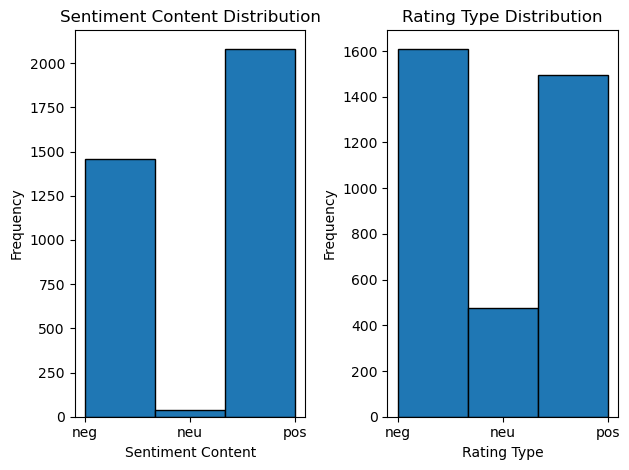

```python
import matplotlib.pyplot as plt

emocont = data['sentiment_content']
rattype = data['Rating_type']
#emotion_content
plt.subplot(1, 2, 1)
plt.hist(emocont, bins=3, edgecolor='black')
plt.xlabel('Sentiment Content')
plt.ylabel('Frequency')
plt.title('Sentiment Content Distribution')
#Rating_type
plt.subplot(1, 2, 2)
plt.hist(rattype, bins=3, edgecolor='black')
plt.xlabel('Rating Type')
plt.ylabel('Frequency')
plt.title('Rating Type Distribution')

plt.tight_layout()
plt.show()
```

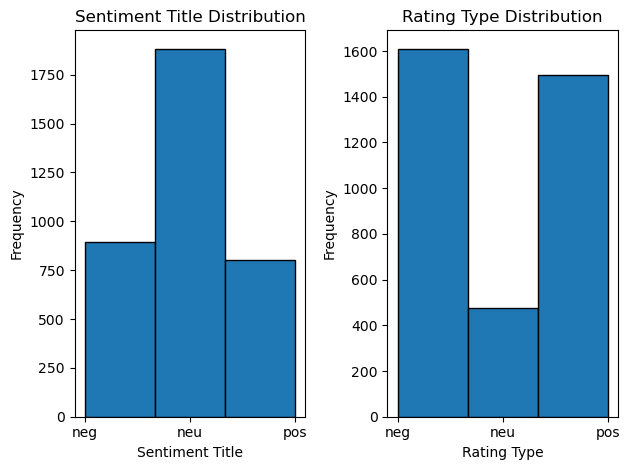

```python
import matplotlib.pyplot as plt

emocont = data['sentiment_title']
rattype = data['Rating_type']
#emotion_title
plt.subplot(1, 2, 1)
plt.hist(emocont, bins=3, edgecolor='black')
plt.xlabel('Sentiment Title')
plt.ylabel('Frequency')
plt.title('Sentiment Title Distribution')
#Rating_type
plt.subplot(1, 2, 2)
plt.hist(rattype, bins=3, edgecolor='black')
plt.xlabel('Rating Type')
plt.ylabel('Frequency')
plt.title('Rating Type Distribution')

plt.tight_layout()
plt.show()
```

Then to evaluate the consistency between ratings and sentiment results, we can calculated an overall accuracy rate.

```python
# Define the Accuracy
data['Accuracy'] = 0
data.loc[data['sentiment_content'] == data['Rating_type'], 'Accuracy'] = 1
print(data)
```

[output not shown]

[output cut: 51 more lines]

```python
data.head(10)
```

|  | Passanger_Name | Flying_month | Route | Rating | Verified | Review_title | Review_content | Traveller_type | Class | compound_title | sentiment_title | compound_content | sentiment_content | Rating_type | Accuracy |
| --- | --- | --- | --- | --- | --- | --- | --- | --- | --- | --- | --- | --- | --- | --- | --- |
| 0 | Paige Boet | June 2023 | New Orleans to London | 1.0 | Trip Verified | The airline lost my luggage | The airline lost my luggage and was absolutely... | Solo Leisure | Economy Class | -0.3182 | neg | -0.7990 | neg | neg | 1 |
| 1 | S Layne | March 2023 | London to Amman | 1.0 | Trip Verified | fully refunded by our travel insurance | We booked on the BA website, round trip flight... | Couple Leisure | Business Class | 0.0000 | neu | 0.0219 | neu | neg | 0 |
| 2 | E Lanewoski | Heathrow to Bodrum | Business Class | 2.0 | Trip Verified | no boarding drinks provided | First time flying with BA business class, neve... | A321 neo | Solo Leisure | -0.2960 | neg | -0.7096 | neg | neg | 1 |
| 3 | Joel Burman | June 2023 | Amman to London | 4.0 | Not Verified | WiFi didn't work | You can buy sandwiches and crisps but don't ex... | Solo Leisure | Economy Class | 0.0000 | neu | -0.5849 | neg | neu | 0 |
| 4 | R Vines | London City to Ibiza | Business Class | 7.0 | Trip Verified | stick with economy | This is a two-for-one review covering economy ... | Embraer 190 | Family Leisure | 0.0000 | neu | 0.9789 | pos | pos | 1 |
| 5 | M King | June 2023 | London to Washington | 1.0 | Trip Verified | Communication is terrible | Absolutely horrible airline. Communication is ... | Couple Leisure | Economy Class | -0.4767 | neg | -0.8932 | neg | neg | 1 |
| 6 | C Dean | Amsterdam to London | Business Class | 1.0 | Trip Verified | delays and cancellations | Having experienced delays and cancellations de... | A350 | Business | 0.0000 | neu | 0.0516 | pos | neg | 0 |
| 7 | Richard Hodges | London Heathrow to Kalamata | Economy Class | 7.0 | Trip Verified | Economy class seating was truly dreadful | Travelled to Heathrow to Kalamata and return j... | Boeing 737 | Couple Leisure | 0.0000 | neu | 0.7900 | pos | pos | 1 |
| 8 | Carol Willmore | June 2023 | London to Funchal | 1.0 | Not Verified | flight failed at every level | This flight failed at every level. We were del... | Couple Leisure | Economy Class | -0.5106 | neg | 0.8693 | pos | neg | 0 |
| 9 | Nadine Kohler | June 2023 | Marseille to Seattle via London Heathrow | 1.0 | Not Verified | BA refuses to make it right | Beware of British Airways and their marketing ... | Family Leisure | Economy Class | 0.0000 | neu | -0.5519 | neg | neg | 1 |

```python
total_rows = len(data)
num_ones = data['Accuracy'].sum()
overall_accuracy = num_ones / total_rows
print(f"Overall accuracy: {overall_accuracy:.2%}")
```

```
Overall accuracy: 70.08%
```

We can see the output accuracy is about 70%. It is enough high, as sentiment anlysis may can not detect the special comments such as rating the high points on purpose but express the negative comments or using the sarcastic comments and so on to express their feeling.

# Prediction for Sentiment Result (Models Comparison)

Then use CountVectorizer to convert the text into a word frequency matrix. Among them, stop_words='english' means to remove common English stop words, max_df=0.5 means to ignore words with document frequency more than 50%, and decode_error='ignore' means to ignore decoding errors. This step generates the word frequency matrix counts_train for the training set.

The word frequency matrix is transformed into a TF-IDF (Word Frequency-Inverse Document Frequency) matrix using TfidfTransformer. This step generates the TF-IDF matrix tfidf_train for the training set.

Using the same parameter configuration, construct the TF-IDF matrix tfidf_valid on the test set. note that the vocabulary of the training set should be used to construct the TF-IDF matrix for the test set to ensure word consistency.

```python
from sklearn.feature_extraction.text import CountVectorizer, TfidfTransformer
from sklearn.tree import DecisionTreeClassifier
from sklearn.ensemble import RandomForestClassifier
from sklearn.ensemble import BaggingClassifier
from sklearn.ensemble import AdaBoostClassifier
from sklearn.metrics import ConfusionMatrixDisplay
from sklearn.model_selection import train_test_split
import random
import numpy as np
X=data['Review_content']
Y=data['sentiment_content']
X_train,X_test,Y_train,Y_test=train_test_split(X,Y,test_size=0.3,random_state=random.randint(0,1000))
```

## RandomForest

```python
# max_df=0.5: ingnore terms with document frequency higher than the given threshold
count_vec1 = CountVectorizer(stop_words = 'english', max_df = 0.5, decode_error = 'ignore')
counts_train = count_vec1.fit_transform(X_train)
tfidftransformer = TfidfTransformer()
tfidf_train = tfidftransformer.fit(counts_train).transform(counts_train)

# Build TFIDF vectors based on testing tweets
count_vec2 = CountVectorizer(vocabulary = count_vec1.vocabulary_, stop_words = 'english', max_df = 0.5, decode_error = 'ignore')
counts_valid = count_vec2.fit_transform(X_test)
tfidf_valid = tfidftransformer.fit(counts_valid).transform(counts_valid)


# Use Random Forest to classify the test set
# n_estimatores controls the no. of trees used, random_state=0: no randomness in feature/instance sampling
clf = RandomForestClassifier(criterion='entropy', n_estimators=300, random_state=0)
clf.fit(tfidf_train, Y_train)
predict_results = clf.predict(tfidf_valid)

#F1-score
'''TP, TN, FN, FP = 0, 0, 0, 0
for i in range(data.shape[0]):
        if Y_test[i] == 'pos' and predict_results[i] == 'pos':
            TP += 1
        elif Y_test[i] == 'neg' and predict_results[i] == 'neg':
            TN += 1
        elif Y_test[i] == 'pos' and predict_results[i] == 'neg':
            FN += 1
        else:
            FP += 1'''
TP = sum((a == 'pos' and b == 'pos') for a, b in zip(Y_test, predict_results))
TN = sum((a == 'neg' and b == 'neg') for a, b in zip(Y_test, predict_results))
FP = sum((a == 'neg' and b == 'pos') for a, b in zip(Y_test, predict_results))
FN = sum((a == 'pos' and b == 'neg') for a, b in zip(Y_test, predict_results))
# print(TP, TN, FN, FP)
precision = TP / (TP + FP)
recall = TP / (TP + FN)
F1 = 2 * recall * precision / (recall + precision)

print("The F-score is:")
print(F1)
```

```
The F-score is:
0.8438690022848437
```

## DecisionTree

```python
clf1= DecisionTreeClassifier(criterion='entropy', random_state=random.randint(0,1000))
clf1.fit(tfidf_train, Y_train)
predict_results = clf1.predict(tfidf_valid)
TP = sum((a == 'pos' and b == 'pos') for a, b in zip(Y_test, predict_results))
TN = sum((a == 'neg' and b == 'neg') for a, b in zip(Y_test, predict_results))
FP = sum((a == 'neg' and b == 'pos') for a, b in zip(Y_test, predict_results))
FN = sum((a == 'pos' and b == 'neg') for a, b in zip(Y_test, predict_results))
# print(TP, TN, FN, FP)
precision = TP / (TP + FP)
recall = TP / (TP + FN)
F1 = 2 * recall * precision / (recall + precision)
print("The F-score is:")
print(F1)
```

```
The F-score is:
0.7457351746547521
```

## Bagging

```python
clf2=BaggingClassifier(DecisionTreeClassifier(max_depth=3),n_estimators=50)
clf2.fit(tfidf_train, Y_train)
predict_results = clf2.predict(tfidf_valid)
TP = sum((a == 'pos' and b == 'pos') for a, b in zip(Y_test, predict_results))
TN = sum((a == 'neg' and b == 'neg') for a, b in zip(Y_test, predict_results))
FP = sum((a == 'neg' and b == 'pos') for a, b in zip(Y_test, predict_results))
FN = sum((a == 'pos' and b == 'neg') for a, b in zip(Y_test, predict_results))
# print(TP, TN, FN, FP)
precision = TP / (TP + FP)
recall = TP / (TP + FN)
F1 = 2 * recall * precision / (recall + precision)
print("The F-score is:")
print(F1)
```

```
The F-score is:
0.7299006323396567
```

## Adaboost

```python
np.random.seed(1)
clf3 = AdaBoostClassifier(DecisionTreeClassifier(max_depth=3),n_estimators=5) # number estimators is the key parameter
clf3.fit(tfidf_train, Y_train)
predict_results = clf3.predict(tfidf_valid)
TP = sum((a == 'pos' and b == 'pos') for a, b in zip(Y_test, predict_results))
TN = sum((a == 'neg' and b == 'neg') for a, b in zip(Y_test, predict_results))
FP = sum((a == 'neg' and b == 'pos') for a, b in zip(Y_test, predict_results))
FN = sum((a == 'pos' and b == 'neg') for a, b in zip(Y_test, predict_results))
# print(TP, TN, FN, FP)
precision = TP / (TP + FP)
recall = TP / (TP + FN)
F1 = 2 * recall * precision / (recall + precision)
print("The F-score is:")
print(F1)
```

```
The F-score is:
0.6872727272727274
```

Then I use emotion analysis to categorize the comments into the eight dimensions of emotion. Based on the score, we can see the comment belong to which emotion category. As emotion analysis helps to understand consumer emotions, improve customer experiences, and then make us have a further understand which features have an impact on their experience so that we can draw a suggestion to our business object and enables us to build better marketing strategies.

## Emotion Analysis

Using the well-known NRC emotion lexicons to do the Emotion Analysis the lexicon can be found from: https://saifmohammad.com/WebPages/NRC-Emotion-Lexicon.htm created by Dr. Saif M. Mohammad and Dr. Peter Turney

```python
#!/usr/bin/env python
# coding: utf-8
import pandas as pd
import re
import nltk

nltk.download('wordnet')
from nltk.stem import WordNetLemmatizer
#negation.csv including the words of not, don't, but, doesn't, except, no
NRC_lexicon_path = 'NRC-Emotion-Lexicon-Wordlevel-v0.92.txt'
negation_path = 'Negation.csv'
negation_words = [word.strip() for word in open(negation_path, 'r')]

# Read lexicon data
lexicon_df = pd.read_csv(NRC_lexicon_path, names=["word", "emotion", "label"], sep='\t', keep_default_na=False)
lexicon_df = lexicon_df.pivot(index='word', columns='emotion', values='label').reset_index()
dataset_path = 'AirlineScrappedReview.csv'

# Read dataset
dataset_df = pd.read_csv(dataset_path)

# Extract the 'Review_title' column as a list of text
review_list = dataset_df['Review_content'].tolist()

token_list = []

for line in review_list:
    tokens = re.split('[ ;.?|:]', line.strip())
    for token in tokens:
        if token != '':
            # Lemmatize the words to better map the lexicon keyword
            lemmatizer = WordNetLemmatizer()
            token = lemmatizer.lemmatize(token)
            token_list.append(token.lower())

mapping_df = lexicon_df.loc[lexicon_df['word'].isin(token_list)]

# Change the polarity of words based on negation
mapping_words = mapping_df['word'].tolist()
for word in mapping_words:
    word_index = token_list.index(word)
    if word_index >= 3:
        for i in range(word_index - 3, word_index):
            if token_list[i] in negation_words:
                negative = mapping_df.loc[mapping_df['word'] == word, 'negative'].copy().item()
                positive = mapping_df.loc[mapping_df['word'] == word, 'positive'].copy().item()

                mapping_df.loc[mapping_df['word'] == word, 'negative'] = positive
                mapping_df.loc[mapping_df['word'] == word, 'positive'] = negative
    else:
        for i in range(0, word_index):
            if token_list[i] in negation_words:
                negative = mapping_df.loc[mapping_df['word'] == word, 'negative'].copy().item()
                positive = mapping_df.loc[mapping_df['word'] == word, 'positive'].copy().item()

                mapping_df.loc[mapping_df['word'] == word, 'negative'] = positive
                mapping_df.loc[mapping_df['word'] == word, 'positive'] = negative

# Calculate emotion scores for each review title
emotions = ['anger', 'anticipation', 'disgust', 'fear', 'joy', 'sadness', 'surprise', 'trust']
emotion_scores = []

for line in review_list:
    tokens = re.split('[ ;.?|:]', line.strip())
    emotion_count = {}
    for emotion in emotions:
        emotion_count[emotion] = 0

    for token in tokens:
        if token != '':
            lemmatizer = WordNetLemmatizer()
            token = lemmatizer.lemmatize(token)
            token = token.lower()
            if token in mapping_df['word'].tolist():
                token_emotion_scores = mapping_df.loc[mapping_df['word'] == token, emotions].values[0]
                for i, emotion in enumerate(emotions):
                    emotion_count[emotion] += token_emotion_scores[i]

    total_count = sum(emotion_count.values())
    if total_count > 0:
        emotion_score = {emotion: count / total_count for emotion, count in emotion_count.items()}
    else:
        emotion_score = {emotion: 0.0 for emotion in emotions}

    emotion_scores.append(emotion_score)

# Create new columns for each emotion score
for emotion in emotions:
    data[emotion] = [score[emotion] for score in emotion_scores]
```

```python
data['MAX_EMOTION'] = data[emotions].idxmax(axis=1)
```

```python
data.head(10)
```

|  | Passanger_Name | Flying_month | Route | Rating | Verified | Review_title | Review_content | Traveller_type | Class | compound_title | ... | Accuracy | anger | anticipation | disgust | fear | joy | sadness | surprise | trust | MAX_EMOTION |
| --- | --- | --- | --- | --- | --- | --- | --- | --- | --- | --- | --- | --- | --- | --- | --- | --- | --- | --- | --- | --- | --- |
| 0 | Paige Boet | June 2023 | New Orleans to London | 1.0 | Trip Verified | The airline lost my luggage | The airline lost my luggage and was absolutely... | Solo Leisure | Economy Class | -0.3182 | ... | 1 | 0.133333 | 0.133333 | 0.133333 | 0.133333 | 0.066667 | 0.200000 | 0.133333 | 0.066667 | sadness |
| 1 | S Layne | March 2023 | London to Amman | 1.0 | Trip Verified | fully refunded by our travel insurance | We booked on the BA website, round trip flight... | Couple Leisure | Business Class | 0.0000 | ... | 0 | 0.057143 | 0.085714 | 0.000000 | 0.228571 | 0.028571 | 0.171429 | 0.057143 | 0.371429 | trust |
| 2 | E Lanewoski | Heathrow to Bodrum | Business Class | 2.0 | Trip Verified | no boarding drinks provided | First time flying with BA business class, neve... | A321 neo | Solo Leisure | -0.2960 | ... | 1 | 0.166667 | 0.333333 | 0.000000 | 0.333333 | 0.000000 | 0.166667 | 0.000000 | 0.000000 | anticipation |
| 3 | Joel Burman | June 2023 | Amman to London | 4.0 | Not Verified | WiFi didn't work | You can buy sandwiches and crisps but don't ex... | Solo Leisure | Economy Class | 0.0000 | ... | 0 | 0.125000 | 0.125000 | 0.000000 | 0.000000 | 0.125000 | 0.000000 | 0.125000 | 0.500000 | trust |
| 4 | R Vines | London City to Ibiza | Business Class | 7.0 | Trip Verified | stick with economy | This is a two-for-one review covering economy ... | Embraer 190 | Family Leisure | 0.0000 | ... | 1 | 0.000000 | 0.130435 | 0.000000 | 0.000000 | 0.173913 | 0.043478 | 0.043478 | 0.608696 | trust |
| 5 | M King | June 2023 | London to Washington | 1.0 | Trip Verified | Communication is terrible | Absolutely horrible airline. Communication is ... | Couple Leisure | Economy Class | -0.4767 | ... | 1 | 0.230769 | 0.000000 | 0.230769 | 0.230769 | 0.000000 | 0.153846 | 0.000000 | 0.153846 | anger |
| 6 | C Dean | Amsterdam to London | Business Class | 1.0 | Trip Verified | delays and cancellations | Having experienced delays and cancellations de... | A350 | Business | 0.0000 | ... | 0 | 0.142857 | 0.071429 | 0.142857 | 0.214286 | 0.000000 | 0.142857 | 0.071429 | 0.214286 | fear |
| 7 | Richard Hodges | London Heathrow to Kalamata | Economy Class | 7.0 | Trip Verified | Economy class seating was truly dreadful | Travelled to Heathrow to Kalamata and return j... | Boeing 737 | Couple Leisure | 0.0000 | ... | 1 | 0.074074 | 0.259259 | 0.074074 | 0.148148 | 0.148148 | 0.148148 | 0.037037 | 0.111111 | anticipation |
| 8 | Carol Willmore | June 2023 | London to Funchal | 1.0 | Not Verified | flight failed at every level | This flight failed at every level. We were del... | Couple Leisure | Economy Class | -0.5106 | ... | 0 | 0.030303 | 0.303030 | 0.030303 | 0.030303 | 0.212121 | 0.090909 | 0.060606 | 0.242424 | anticipation |
| 9 | Nadine Kohler | June 2023 | Marseille to Seattle via London Heathrow | 1.0 | Not Verified | BA refuses to make it right | Beware of British Airways and their marketing ... | Family Leisure | Economy Class | 0.0000 | ... | 1 | 0.026316 | 0.289474 | 0.026316 | 0.078947 | 0.105263 | 0.105263 | 0.131579 | 0.236842 | anticipation |

10 rows × 24 columns

```python
data['MAX_EMOTION'].value_counts()
```

```
trust           1947
anticipation     905
sadness          185
joy              171
anger            164
fear             144
disgust           45
surprise          19
Name: MAX_EMOTION, dtype: int64
```

Draw a histogram to see the whole Emotion content distribution.

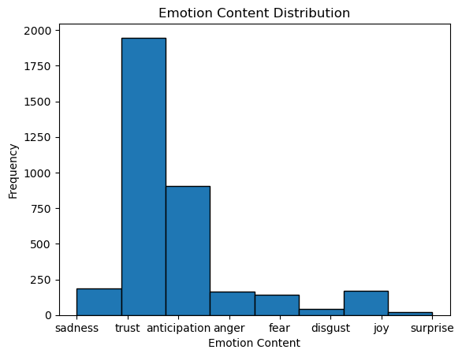

```python
emotion = data['MAX_EMOTION']
plt.hist(emotion, bins=8, edgecolor='black')
plt.xlabel('Emotion Content')
plt.ylabel('Frequency')
plt.title('Emotion Content Distribution')
```

```python
output_file = 'emotion analysis.csv'
data.to_csv(output_file, index=False)
print(f"Data saved to {output_file}")
```

```
Data saved to emotion analysis.csv
```

```python
X=data['Review_content']
Y=data['MAX_EMOTION']
X_train,X_test,Y_train,Y_test=train_test_split(X,Y,test_size=0.3,random_state=random.randint(0,1000))
```

# Prediction for Emotional Analysis Result (Models Comparison)

Similar as the sentiment analysis, we do the models comparison, to provide the best model for the further analysis if the company want to predict the comments, and can keep an eye on the company's overall reputation and public opinion in the market.

# RandomForest

```python
# max_df=0.5: ingnore terms with document frequency higher than the given threshold
count_vec1 = CountVectorizer(stop_words = 'english', max_df = 0.5, decode_error = 'ignore')
counts_train = count_vec1.fit_transform(X_train)
tfidftransformer = TfidfTransformer()
tfidf_train = tfidftransformer.fit(counts_train).transform(counts_train)

# Build TFIDF vectors based on testing tweets
#validation_labels = validation_set['Label'].values
#validation_features = validation_set['Text'].values
count_vec2 = CountVectorizer(vocabulary = count_vec1.vocabulary_, stop_words = 'english', max_df = 0.5, decode_error = 'ignore')
counts_valid = count_vec2.fit_transform(X_test)
tfidf_valid = tfidftransformer.fit(counts_valid).transform(counts_valid)


# Use Random Forest to classify the test set
# n_estimatores controls the no. of trees used, random_state=0: no randomness in feature/instance sampling
clf = RandomForestClassifier(criterion='entropy', n_estimators=300, random_state=0)
clf.fit(tfidf_train, Y_train)
predict_results = clf.predict(tfidf_valid)
```

```python
from sklearn.metrics import classification_report
report = classification_report(Y_test, predict_results)
print("\nClassification Report:\n", report)
```

```
Classification Report:
               precision    recall  f1-score   support

       anger       1.00      0.05      0.09        42
anticipation       0.66      0.22      0.33       264
     disgust       1.00      0.06      0.11        17
        fear       1.00      0.03      0.05        36
         joy       1.00      0.08      0.14        53
     sadness       0.00      0.00      0.00        67
    surprise       0.00      0.00      0.00         8
       trust       0.59      0.98      0.73       587

    accuracy                           0.60      1074
   macro avg       0.66      0.18      0.18      1074
weighted avg       0.62      0.60      0.50      1074
```

# DecisionTree

```python
clf1= DecisionTreeClassifier(criterion='entropy', random_state=random.randint(0,1000))
clf1.fit(tfidf_train, Y_train)
predict_results = clf1.predict(tfidf_valid)

report = classification_report(Y_test, predict_results)
print("\nClassification Report:\n", report)
```

```
Classification Report:
               precision    recall  f1-score   support

       anger       0.09      0.12      0.10        42
anticipation       0.41      0.49      0.45       264
     disgust       0.14      0.06      0.08        17
        fear       0.15      0.17      0.16        36
         joy       0.23      0.19      0.21        53
     sadness       0.18      0.09      0.12        67
    surprise       0.00      0.00      0.00         8
       trust       0.67      0.66      0.66       587

    accuracy                           0.51      1074
   macro avg       0.23      0.22      0.22      1074
weighted avg       0.50      0.51      0.50      1074
```

# Bagging

```python
clf2=BaggingClassifier(DecisionTreeClassifier(max_depth=3),n_estimators=50)
clf2.fit(tfidf_train, Y_train)
predict_results = clf2.predict(tfidf_valid)

report = classification_report(Y_test, predict_results)
print("\nClassification Report:\n", report)
```

```
Classification Report:
               precision    recall  f1-score   support

       anger       0.00      0.00      0.00        42
anticipation       0.63      0.32      0.43       264
     disgust       0.00      0.00      0.00        17
        fear       0.00      0.00      0.00        36
         joy       0.00      0.00      0.00        53
     sadness       0.00      0.00      0.00        67
    surprise       0.00      0.00      0.00         8
       trust       0.58      0.93      0.71       587

    accuracy                           0.59      1074
   macro avg       0.15      0.16      0.14      1074
weighted avg       0.47      0.59      0.50      1074
```

# AdaBoost

```python
np.random.seed(1)
clf3 = AdaBoostClassifier(DecisionTreeClassifier(max_depth=3),n_estimators=5) # number estimators is the key parameter
clf3.fit(tfidf_train, Y_train)

report = classification_report(Y_test, predict_results)
print("\nClassification Report:\n", report)
```

```
Classification Report:
               precision    recall  f1-score   support

       anger       0.00      0.00      0.00        42
anticipation       0.63      0.32      0.43       264
     disgust       0.00      0.00      0.00        17
        fear       0.00      0.00      0.00        36
         joy       0.00      0.00      0.00        53
     sadness       0.00      0.00      0.00        67
    surprise       0.00      0.00      0.00         8
       trust       0.58      0.93      0.71       587

    accuracy                           0.59      1074
   macro avg       0.15      0.16      0.14      1074
weighted avg       0.47      0.59      0.50      1074
```

# Word Cloud

After did the Sentiment Analysis and the Emotion Analysis, we can base on the Review_content and use the Word Cloud to find out the aspects that customers focus on from the comments, as the accuracy of the sentiment analysis align with the rating is enough high (70% accuracy). To improve our service, I focus on comments from customers who are marked as negative, extract sentiment words and nouns, and then use these word pairs for high-frequency word statistics and word clouds for visualization.

```python
import pandas as pd
import nltk
from nltk.corpus import stopwords
from nltk.tokenize import word_tokenize
from nltk.tag import pos_tag
from wordcloud import WordCloud
import matplotlib.pyplot as plt
import re
```

```python
data = pd.read_csv('emotion analysis.csv')
reviews = data['Review_content']
```

```python
def extract_keywords(text):
    # divide the words
    tokens = word_tokenize(text)

    # delete the stop words
    stop_words = set(stopwords.words('english'))
    tokens = [token.lower() for token in tokens if token.lower() not in stop_words]

    # extract the emotion word and noun
    tagged_tokens = pos_tag(tokens)
    keywords = [word for word, pos in tagged_tokens if pos.startswith('NN') or pos == 'JJ']

    return keywords
```

```python
reviews_neg = [review for review,sentimentkind in zip(data['Review_content'], data['sentiment_content']) if sentimentkind == 'neg']
```

```python
all_keywords_neg = []
for review in reviews_neg:
    keywords = extract_keywords(review)
    all_keywords_neg.extend(keywords)

word_freq_neg = nltk.FreqDist(all_keywords_neg)
```

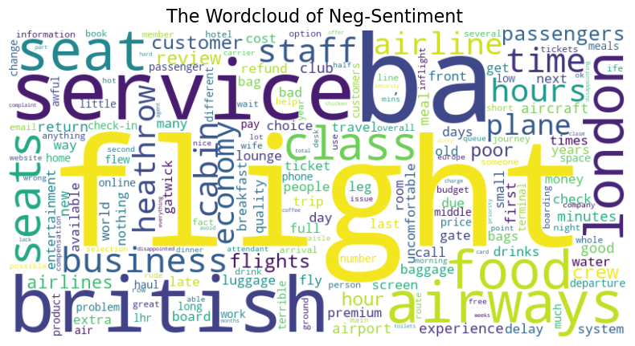

```python
wordcloud = WordCloud(width=800, height=400, background_color='white').generate_from_frequencies(word_freq_neg)
plt.figure(figsize=(10, 5))
plt.imshow(wordcloud, interpolation='bilinear')
plt.axis("off")
plt.title('The Wordcloud of Neg-Sentiment ',fontsize=16)
plt.show()
```

```python
top_keywords_neg = word_freq_neg.most_common(20)
top_keywords_neg
```

```
[('flight', 2775),
 ('ba', 1651),
 ('service', 1097),
 ('british', 970),
 ('airways', 956),
 ('seat', 899),
 ('london', 831),
 ('food', 823),
 ('class', 817),
 ('seats', 792),
 ('business', 706),
 ('time', 683),
 ('staff', 666),
 ('cabin', 623),
 ('hours', 585),
 ('heathrow', 548),
 ('airline', 543),
 ('economy', 508),
 ('plane', 466),
 ('passengers', 458)]
```

From the word cloud map, we can see that seven meaningful words, service, seat, food, time, staff, cabin, and passengers, appear most frequently in the comments of negative customers. Other less meaningful words, such as the word: BA is abbreviations for the companies we analyze. These words have little to do with the sentiment score we're going to return to, so we'll ignore them. Then we do the regression between the keywords and the sentiment scope to see which features are more important.

# Analyse the Relationship between Keywords and Sentiment Score

```python
keywords = ['service', 'seat', 'food', 'time', 'staff', 'cabin', 'passengers']
```

```python
data_dummy = data[['compound_content','Review_content']]
data_dummy
```

|  | compound_content | Review_content |
| --- | --- | --- |
| 0 | -0.7990 | The airline lost my luggage and was absolutely... |
| 1 | 0.0219 | We booked on the BA website, round trip flight... |
| 2 | -0.7096 | First time flying with BA business class, neve... |
| 3 | -0.5849 | You can buy sandwiches and crisps but don't ex... |
| 4 | 0.9789 | This is a two-for-one review covering economy ... |
| ... | ... | ... |
| 3575 | 0.9129 | LHR-HKG on Boeing 747 - 23/08/12. Much has bee... |
| 3576 | -0.8763 | Just got back from Bridgetown Barbados flying ... |
| 3577 | -0.2003 | LHR-JFK-LAX-LHR. Check in was ok apart from be... |
| 3578 | 0.9864 | HKG-LHR in New Club World on Boeing 777-300 - ... |
| 3579 | 0.0933 | YYZ to LHR - July 2012 - I flew overnight in p... |

3580 rows × 2 columns

```python
for keyword in keywords:
    data_dummy[keyword] = data_dummy['Review_content'].apply(lambda x: 1 if re.search(keyword, str(x), re.IGNORECASE) else 0)
data_dummy
```

|  | compound_content | Review_content | service | seat | food | time | staff | cabin | passengers |
| --- | --- | --- | --- | --- | --- | --- | --- | --- | --- |
| 0 | -0.7990 | The airline lost my luggage and was absolutely... | 0 | 0 | 0 | 1 | 0 | 0 | 0 |
| 1 | 0.0219 | We booked on the BA website, round trip flight... | 1 | 1 | 0 | 1 | 0 | 0 | 0 |
| 2 | -0.7096 | First time flying with BA business class, neve... | 0 | 0 | 0 | 1 | 0 | 0 | 0 |
| 3 | -0.5849 | You can buy sandwiches and crisps but don't ex... | 0 | 0 | 1 | 0 | 0 | 0 | 0 |
| 4 | 0.9789 | This is a two-for-one review covering economy ... | 0 | 1 | 0 | 0 | 0 | 1 | 0 |
| ... | ... | ... | ... | ... | ... | ... | ... | ... | ... |
| 3575 | 0.9129 | LHR-HKG on Boeing 747 - 23/08/12. Much has bee... | 0 | 0 | 1 | 1 | 0 | 1 | 0 |
| 3576 | -0.8763 | Just got back from Bridgetown Barbados flying ... | 0 | 0 | 1 | 0 | 1 | 0 | 0 |
| 3577 | -0.2003 | LHR-JFK-LAX-LHR. Check in was ok apart from be... | 1 | 1 | 1 | 0 | 0 | 0 | 0 |
| 3578 | 0.9864 | HKG-LHR in New Club World on Boeing 777-300 - ... | 0 | 1 | 1 | 1 | 0 | 1 | 0 |
| 3579 | 0.0933 | YYZ to LHR - July 2012 - I flew overnight in p... | 0 | 1 | 1 | 0 | 0 | 0 | 0 |

3580 rows × 9 columns

```python
dummy_feature = ['service', 'seat', 'food', 'time', 'staff', 'cabin', 'passengers']
target = ['compound_content']
x = data_dummy[dummy_feature]
y = data_dummy[target]
```

## Apply sklearn.linear

```python
from sklearn.linear_model import LinearRegression
from sklearn.model_selection import train_test_split
x_train, x_test, y_train, y_test = train_test_split(x, y,
test_size=0.30, random_state=0)

lin_reg = LinearRegression()
lin_reg.fit(x_train, y_train)

print(lin_reg.coef_)
print(lin_reg.intercept_)
```

```
[[-0.00298762  0.056533    0.15886395  0.1438536  -0.04885124  0.11787597
  -0.1755481 ]]
[-0.00527394]
```

```python
from sklearn.metrics import mean_absolute_error
y_pred=lin_reg.predict(x_test)
MAE = mean_absolute_error(y_test,y_pred)
print(MAE)
```

```
0.7038536713096997
```

## Apply OLS linear regression

```python
import statsmodels.api as sm

x = sm.add_constant(x)
model = sm.OLS(y, x).fit()

print(model.summary())
```

```
                            OLS Regression Results
==============================================================================
Dep. Variable:       compound_content   R-squared:                       0.043
Model:                            OLS   Adj. R-squared:                  0.041
Method:                 Least Squares   F-statistic:                     23.08
Date:                Sat, 20 Apr 2024   Prob (F-statistic):           7.91e-31
Time:                        17:44:29   Log-Likelihood:                -4094.2
No. Observations:                3580   AIC:                             8204.
Df Residuals:                    3572   BIC:                             8254.
Df Model:                           7
Covariance Type:            nonrobust
==============================================================================
                 coef    std err          t      P>|t|      [0.025      0.975]
------------------------------------------------------------------------------
const         -0.0367      0.028     -1.294      0.196      -0.092       0.019
service        0.0044      0.026      0.173      0.863      -0.046       0.055
seat           0.0657      0.027      2.478      0.013       0.014       0.118
food           0.1631      0.026      6.261      0.000       0.112       0.214
time           0.1510      0.026      5.866      0.000       0.101       0.201
staff         -0.0372      0.028     -1.338      0.181      -0.092       0.017
cabin          0.1667      0.027      6.109      0.000       0.113       0.220
passengers    -0.1379      0.032     -4.245      0.000      -0.202      -0.074
==============================================================================
Omnibus:                    23623.046   Durbin-Watson:                   1.916
Prob(Omnibus):                  0.000   Jarque-Bera (JB):              395.271
Skew:                          -0.333   Prob(JB):                     1.47e-86
Kurtosis:                       1.514   Cond. No.                         4.45
==============================================================================

Notes:
[1] Standard Errors assume that the covariance matrix of the errors is correctly specified.
```

# EXtract High TF-IDF words (Other ways to select the keywords)

Other way to check about the keywords: we can calculate the TF-IDF of the words in each document, then average them over the entire document and arrange them according to their mean. In this way, we can obtain keywords that retain both importance and representativeness. Comparing this result with our keywords, we can see that our keywords still maintain sufficient importance.

```python
from sklearn.feature_extraction.text import TfidfVectorizer
vectorizer = TfidfVectorizer(stop_words='english', max_df=0.5, decode_error='ignore')
X = vectorizer.fit_transform(data['Review_content'])

# Get the list of feature words and corresponding TF-IDF weights
feature_names = vectorizer.get_feature_names_out()
tfidf_matrix = X.toarray()

# Calculates the average TF-IDF weights for the entire document collection, packaging the feature words and corresponding average TF-IDF
avg_tfidf_weights = tfidf_matrix.mean(axis=0)
word_weights = list(zip(feature_names, avg_tfidf_weights))

# Sorted according to TF-IDF weights
sorted_word_weights = sorted(word_weights, key=lambda x: x[1], reverse=True)
sorted_word_weights
```

[output not shown]

[output cut: 946 more lines]

[output not shown]